# CO2 ELEVATION, CANOPY PHOTOSYNTHESIS, ANDOPTIMAL LEAF AREA INDEX - Hirose - 1997 - Ecology - Wiley Online Library

### Daily canopy photosynthesis

Daily rates of canopy photosynthesis were calculated based on the actual distribution of leaf area and leaf N (Fig. 1) with the leaf photosynthesis model presented above. Distribution of leaf area determines light climate in the canopy and leaf N determines photosynthetic capacity of leaves. Incident PPFD for each leaf in the canopy was evaluated as a function of cumulative LAI with Eq. 5. The extinction coefficient (*K*) changed depending on stands: *Abutilon,* 1.12 and 0.76; *Ambrosia,* 1.02 and 1.07; mixed stands, 1.12 and 0.94 on day 39 and 53, respectively. There was no significant difference in *K* between the two CO<sub>2</sub> levels (data not shown). Transmittance (τ) was determined for each leaf with Eq. 2 and a leaf N–chlorophyll relationship (Eq. 10). Fig. 5 shows daily rates of canopy photosynthesis of *Abutilon* and *Ambrosia* in monospecific and mixed stands grown under ambient and elevated CO<sub>2</sub> conditions. CO<sub>2</sub> elevation increased daily canopy photosynthesis by 30–50%. On day 39 *Ambrosia* had higher canopy photosythesis than *Abutilon,* whereas the difference was diminished between the two monospecific stands on day 53. This is due to the faster leaf area development with higher N content in *Ambrosia* (Fig. 1), enabling this species to attain higher photosynthetic rates. There was no significant difference in leaf area and leaf N between the two species on day 53.

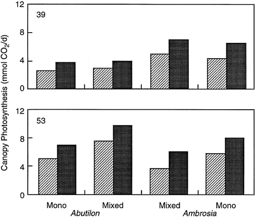

**Figure 5**

Open in figure viewer[PowerPoint](https://esajournals.onlinelibrary.wiley.com/action/downloadFigures?id=i0012-9658-78-8-2339-f05&partId=&doi=10.1890%2F0012-9658%281997%29078%5B2339%3ACECPAL%5D2.0.CO%3B2)

Daily rates of canopy photosynthesis of plants in the monospecific and mixed stands of *Abutilon theophrasti* and *Ambrosia artemisiifolia* on day 39 and 53, when plants were grown under ambient (360 μL/L CO<sub>2</sub>, lightly shaded) or elevated (700 μL/L CO<sub>2</sub>, darkly shaded) CO<sub>2</sub> conditions. Multiplication by 100 (monospecific stands) or by 50 (mixed stands) gives values per 1 m<sup>2</sup> of ground area.

Estimated values of canopy photosynthesis (Fig. 5) were strongly correlated with rates of carbon gain (*r*<sup>2</sup> = 0.77, *n* = 8; Fig. 6) measured using growth analysis in the same stands (growth analysis data from Fig. 3 in Hirose et al. 1996*b*). The correspondence between these two measurements is particularly striking, as the photosynthetic parameters used to parameterize our model were obtained from plants grown independently of those used for growth analysis (see *Materials and methods*). In addition, four of the eight data points were from mixed-species stands in which a simple linear model of light interception was used to estimate the relative performance of the two species. These results validate the structure and parameterization of our model for predicting canopy-level photosynthesis, and support its use for the assessment of optimal LAI below.

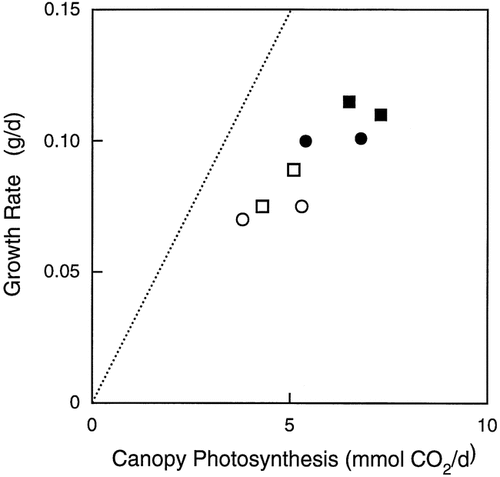

**Figure 6**

Open in figure viewer[PowerPoint](https://esajournals.onlinelibrary.wiley.com/action/downloadFigures?id=i0012-9658-78-8-2339-f06&partId=&doi=10.1890%2F0012-9658%281997%29078%5B2339%3ACECPAL%5D2.0.CO%3B2)

Comparison of the mean of canopy photosynthesis values (abscissa) estimated from physiological parameters on days 39 and 53 (see Fig. 5) with absolute plant growth rates (ordinate) determined by growth analysis (see Fig. 3 of Hirose et al. 1996*b*). ○, *Abutilon theophrasti* at 360 μL/L CO<sub>2</sub>; •, *Abutilon* at 700 μL/L CO<sub>2</sub>; □, *Ambrosia artemisiifolia* at 360 μL/L CO<sub>2</sub>; ▪, *Ambrosia* at 700 μL/L CO<sub>2</sub>. Dotted line indicates equivalence of 1 mol CO<sub>2</sub> with 30 g dry mass.

## Discussion

### Modeling of leaf photosynthesis

Rectangular hyperbolic equations fit the present data for *P*<sub>max</sub>–*N*<sub>L</sub> relationships better than the linear equations that have been used by many authors (e.g., Hirose and Werger 1987*a*, Pons et al. 1990, Anten et al. 1995*b*). Curvilinear relationships between *P*<sub>max</sub> and *N*<sub>L</sub> were also obtained by several authors (Gulmon and Chu 1981, Evans 1983, Makino et al. 1988, Hilbert et al. 1991, Hikosaka and Terashima 1995). Diminishing returns of carbon gain with increasing *N*<sub>L</sub> may be due to increased PPFD limitation at higher *N*<sub>L</sub>. Hirose and Werger (1987*a*) showed strong curvilinear relationships between net photosynthesis and *N*<sub>L</sub> when PPFD was low. Our plants were grown in the glasshouse with maximum PPFD less than 1200 μmol·m<sup>−2</sup>·s<sup>−1</sup> and *P*<sub>max</sub> was measured at a PPFD of 1000–1200 μmol·m<sup>−2</sup>·s<sup>−1</sup>, which might have still limited photosynthesis of leaves with high *N*<sub>L</sub>. Leaf photosynthesis significantly increased with CO<sub>2</sub> elevation. Proportional increase in *P*<sub>max</sub> with CO<sub>2</sub> elevation, however, was higher at higher *N*<sub>L</sub>. The 20–30% increase found in the range of *N*<sub>L</sub> = 1.0–1.5 g N/m<sup>2</sup> in *Abutilon* is in good agreement with a review of Cure and Acock (1986) who showed that doubling CO<sub>2</sub> led, on average, to a 29% increase in leaf photosynthesis after acclimation. Tissue et al. (1995) reported that *Abutilon* grown in elevated CO<sub>2</sub> increased net photosynthesis by 27% relative to growth at ambient CO<sub>2</sub>. Because *N*<sub>L</sub> was not increased with CO<sub>2</sub> elevation, the increase in leaf photosynthesis with CO<sub>2</sub> elevation was solely due to increased photosynthetic activity per unit leaf N.

Linear equations were applied to the relationships between *R*<sub>d</sub> and *N*<sub>L</sub>. A linear relationship is expected if protein turnover represents a major fraction of maintenance respiration in the canopy (Penning de Vries 1975). Several authors have reported linear relationships between *R*<sub>d</sub> and *N*<sub>L</sub> (Hirose and Werger 1987*a*, Pons et al. 1990, Anten et al. 1995*b*). CO<sub>2</sub> elevation slightly but significantly increased *R*<sub>d</sub> in *Abutilon,* while no significant difference was found in *R*<sub>d</sub> of *Ambrosia.* No consistent results have been reported on the effect of CO<sub>2</sub> elevation on *R*<sub>d</sub> (Amthor 1997): *R*<sub>d</sub> increased in perennial ryegrass (Nijs et al. 1988) and cotton (Thomas et al. 1993), decreased in *Rumex crispus* (Amthor et al. 1992) and soybean (Bunce and Ziska 1996), or was not significantly changed in plantain (Poorter et al. 1988) and a saltmarsh sedge (Long and Drake 1991). Increase in carbohydrate supply with CO<sub>2</sub> elevation does not seem to lead to increased *R*<sub>d</sub> (see Lambers 1985, Farrar and Williams 1991).

Quantum yield calculated on an absorbed light basis (φ<sub>abs</sub>) is a function of (a) the efficiency of energy transduction into NADPH (reduced form of nicotinamide adenine dinucleotide phosphate) and ATP (adenosine triphosphate) on the photosynthetic membrane and (b) the metabolic pathways in which this reducing and phosphorylating potential is utilized (Long and Drake 1991). In the ambient atmospheric CO<sub>2</sub> concentration, φ<sub>abs</sub> shows remarkable constancy among C<sub>3</sub> species, while in an atmosphere with an elevated CO<sub>2</sub> concentration, φ<sub>abs</sub> is expected to rise in proportion to the increase in the ratio of carboxylations of RuBP (ribulose-1,5-bis-phosphate) to oxygenations (Farquhar et al. 1980). In this paper we assumed φ<sub>abs</sub> = 0.05 at the atmospheric CO<sub>2</sub> concentration of 360 μL/L and φ<sub>abs</sub> = 0.07 at 700 μL/L following the data in Ehleringer and Björkman (1977). They obtained these values in a short-term experiment. Long and Drake (1991) suggested that tissues developed in an elevated CO<sub>2</sub> atmosphere show an acclimatory decrease in φ<sub>abs</sub> and reported φ<sub>abs</sub> = 0.065 (351 μL/L) and 0.078 (680 μL/L) in *Scirpus olneyi.* Thus, the difference in φ<sub>abs</sub> between the two CO<sub>2</sub> levels may be smaller than that used in our model (see sensitivity analysis in *Optimal LAI* below). The initial slope was a saturating function of *N*<sub>L</sub>. Pons et al. (1990) obtained the initial slope as a rectangular hyperbolic function of *N*<sub>L</sub> through regression, while Hikosaka and Terashima (1995) derived such functions from their model of optimal N allocation among photosynthetic proteins.

### Nitrogen distribution and canopy photosynthesis

Applying the leaf photosynthesis model to the actual distribution of leaf area and N through the canopy, we calculated daily rates of canopy photosynthesis of the monospecific and mixed stands of *Abutilon* and *Ambrosia.* Distribution of leaf N in the canopy (Fig. 1) reflects leaf area distribution and N content per leaf area (*N*<sub>L</sub>). At the later growth stage when the canopy was fully developed, *N*<sub>L</sub> was higher in upper layers in the canopy, and thus the mode of leaf N shifts to a higher position than the mode of leaf area distribution (Hirose et al. 1988, 1989). Higher *N*<sub>L</sub> in upper layers is due to reallocation of N from lower layers with canopy development. Such reallocation leads to maximization of photosynthetic returns of the whole canopy, because leaves in the microenvironments receiving the highest PPFD have the highest N concentration (Field 1983, Hirose and Werger 1987*b*). The coefficient of N allocation (*K*<sub>a</sub>; Hirose and Werger 1987*b*) increased from 0.01 to 0.51 in *Abutilon* and 0.42 to 0.88 in *Ambrosia* in the period from day 39 to 53. Increase in *K*<sub>a</sub> with stand development was also observed in *Carex acutiformis* (Hirose et al. 1989). *Ambrosia* had higher *K*<sub>a</sub> than *Abutilon* (*P* < 0.01), but no significant effect of doubling CO<sub>2</sub> on *K*<sub>a</sub> was observed. *K*<sub>a</sub> did not change in either species when grown in a mixed stand. Anten et al. (1995*a*) showed that the optimal pattern of N allocation in the canopy is determined by the extinction coefficient for light and the total amount of free (i.e., translocatable) N, and is independent of the slope of *P*<sub>max</sub> against *N*<sub>L</sub>. The absence of a significant CO<sub>2</sub> effect on *K*<sub>a</sub> in this experiment is consistent with this prediction, since elevated CO<sub>2</sub> altered the slope of *P*<sub>max</sub>–*N*<sub>L</sub> relationships, while other characteristics such as *K* and leaf N remained virtually unchanged, though the actual distribution of N is always more uniform than the optimal one (data not shown).

Rates of canopy carbon gain based on growth analysis were 40–50% lower than those based on physiological parameters (Fig. 6). This difference may be accounted for by several factors, including consumption of photosynthates in respiratory processes of nonphotosynthetic organs (Lambers 1985), exclusion of root mass from growth analysis, which might have led to ∼10% underestimation (cf. Coleman and Bazzaz 1992), and reductions due to cloudiness during the growth period, as the calculated values assumed full sun. Assumption of average diffuse PPFD in the canopy (Eq. 5) in the calculations would also overestimate photosynthesis because of the convex photosynthesis–light response curve (Spitters 1986). CO<sub>2</sub> elevation increased daily canopy photosynthesis by 30–50%, which is comparable to a 25–45% increase in a mixed-meadow model ecosystem (Overdieck and Lieth 1986), 54% increase in a rice stand (Allen et al. 1989), 77% increase in perennial ryegrass (Nijs et al. 1988), and 40–88% increase in a salt marsh community (Drake and Leadley 1991). The increase in growth rate under high CO<sub>2</sub> conditions (Hirose et al. 1996*b*) was explained by the increased photosynthetic rate per leaf area, which in turn was explained by the increase in photosynthetic N use efficiency of leaves. Photosynthetic N use efficiency would increase by 60% with doubling CO<sub>2</sub> if leaf N was optimally partitioned among photosynthetic proteins (K. Hikosaka, *personal communication*).

### Optimal LAI

The present experiment did not show an increase in LAI with CO<sub>2</sub> elevation. Hirose et al. (1996*b*) hypothesized that leaf area development is controlled by N availability rather than by atmospheric CO<sub>2</sub> concentrations. This hypothesis is consistent with a recent experiment on the effect of CO<sub>2</sub> and N availability in rice plants (Ziska et al. 1996), in which LAI increased with increasing addition of N but not with CO<sub>2</sub> elevation at equal levels of N availability. Hättenschwiler and Körner (1996) also showed that the rate of leaf area production was not significantly changed by CO<sub>2</sub>, but was significantly increased with the rate of N supply in understory plants. However, several authors predicted an increase in LAI with CO<sub>2</sub> elevation, because CO<sub>2</sub> elevation leads to an increase in the initial slope of the light-response curve and thus to a reduction of the light compensation point (LCP; Pearcy and Björkman 1983, Long and Drake 1991). A reduced LCP would allow additional leaf area development deep in the canopy and increase overall LAI. However, LCP depends on the change in dark respiration as well as the initial slope. The LCP may increase if CO<sub>2</sub> elevation increases dark respiration. The other factor that might be involved in determining the LAI at high CO<sub>2</sub> is N availability. If the availability of N is limited, N may be reallocated faster to the top of the canopy, counteracting the hypothesis of improved carbon balance in shade leaves (Long and Drake 1991). In a preliminary analysis we found that optimal LAI did not change greatly under elevated CO<sub>2</sub> (Hirose et al. 1996*a*). In the rest of this paper we will examine the effect of CO<sub>2</sub> elevation on the optimal LAI in relation to N availability and evaluate the relative sensitivity of optimal LAI and canopy photosynthesis to variation in leaf photosynthetic parameters. Studying optimal LAI helps understand the factors that determine LAI and is thus an ideal approach to elucidate the mechanism by which CO<sub>2</sub> elevation influences LAI.

For a fixed amount of leaf area and N availability for leaf growth, daily canopy photosynthesis is maximized when in every microsite in the canopy, the rate of change of daily carbon gain with changing leaf N is equal:

((11))

∂*P*<sub>L,day</sub>/∂*N*<sub>L</sub> = λ

where *P*<sub>L,day</sub> is daily carbon gain of a leaf in the canopy and λ is a Lagrange multiplier (Field 1983). Eq. 11 defines the optimal distribution of N through the canopy. On the other hand, we consider optimal LAI to be the LAI that maximizes the daily rate of canopy photosynthesis for a fixed amount of N.

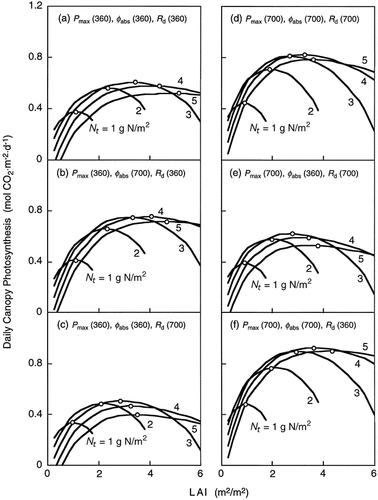

**Figure 7**

Open in figure viewer[PowerPoint](https://esajournals.onlinelibrary.wiley.com/action/downloadFigures?id=i0012-9658-78-8-2339-f07&partId=&doi=10.1890%2F0012-9658%281997%29078%5B2339%3ACECPAL%5D2.0.CO%3B2)

Daily rates of canopy photosynthesis per unit ground area as a function of leaf area index (LAI, abscissa) and leaf nitrogen availability per unit ground area (*N*<sub>t</sub> [g N/m<sup>2</sup>], numbers labeling the curves). Parameter values in the leaf photosynthesis model of *Abutilon theophrasti* are applied for the simulation. Each panel (a–f) represents a different combination of *P*<sub>max</sub>, φ<sub>abs</sub>, and *R*<sub>d</sub> at 360 or 700 μL/L CO<sub>2</sub>.

## Acknowledgments

We thank N. P. R. Anten and K. Hikosaka for discussion and comments. Thanks are also due to R. Yambe for N analyses and figure drawings. This study was partly supported by grants-in-aid of the Japan Ministry of Education, Science and Culture to T. Hirose and by US-National Science Foundation grants to D. D. Ackerly and F. A. Bazzaz.

## Citing Literature

[Download PDF](https://esajournals.onlinelibrary.wiley.com/doi/pdf/10.1890/0012-9658%281997%29078%5B2339%3ACECPAL%5D2.0.CO%3B2)

back

View PDF